# Heterogeneous Regression Ensemble to Determine the Effects of Alcohol on Student GPA

DA5030 Signature Project

Larkin, Yvonne

Fall 2025 / December 3, 2025

## Signature Project : [Effects of Alcohol on Student Performance](https://www.kaggle.com/datasets/joshuanaude/effects-of-alcohol-on-student-performance) [^1]

# 1. Business Understanding :

Objective : Build a heterogeneous ensemble model of homogeneous ensembles to predict a student’s GPA based on provided predictor features with the goal of seeing alcohol effect on student performance.

Overall question is “Does Alcohol impact a student’s grades? If so, is it predictable based on other metrics?” It is unclear whether there is a quantifiable prediction assessment for the GPA given a set number of predictors. If it is able to be quantified that would be great, and can assists in helping students who may have drinking habits that negatively affect their performance in school, and potentially identify specific areas that disproportionately increase this impact.

# 2. Data Understanding :

### Data Background Information :

- Dataset found on kaggle.com
- License : Open Database Contents
- Uploaded March 06, 2024 (coverage end date March 24, 2024)
- authors/publishers : Joshua Naude and Jordan Bendeman
- data from : Department of Statistics and Actuarial Science, Stellenbosch University, South Africa
- Google Forms Survey filled out by Stellenbosch University students

#### Dataset Specifics: Gathered from kaggle [^2]

- **Suggested Target** Response Variable ($Y_i$) on kaggle : “to predict students academic performance (grades) using a multilinear regression model built on predictors mentioned based on 2023 student information” stated as :
  - Study_Year_Avg : numeric continuous : the academic average the student achieved in 2023 in percentage
    - [0,100]
- Independent Variables ($X_i$) : Categorical and Numeric
  - isFemale : the isFemale/gender of the studens
    - Male, Female
  - Matric_Avg : students matric [^3] average in percentage
    - [0,100]
  - Study_Year : the student’s current year of academic studies
    - 1st, 2nd, 3rd, 4th, Postgraduate
  - faculty Department under which the student’s degree falls under at Stellenbasch university (listed in no particular order)
    1. AgriSciences
    2. Arts & Social Sciences
    3. Economic & Management Sciences
    4. Education
    5. Engineering
    6. Law
    7. Medicine & Health Sciences
    8. Military Science
    9. Science
    10. Theology
  - Accom_Status : accommodations status of the student indicates if the student stays in Stellenbosch University accommodation or other private accommodation
    - Private, Non-private
  - mon_allowance : How much the student receives as a monthly allowance while in Stellenbasch; available bins
    - 4001-5000, 5001-6000, 6001-7000, 7001-8000, 8000+
  - Scholarship : Is the student on some kind of funding program or not
    - Yes, No
  - Wkly_Stdy_Hrs : The amount of time a student spends studying over and above their weekly lectures
    - 0, 1-3, 3-5, 5-8, 8+
  - Socializing_Freq : How often the student goes out socializing with their friends. This could be clubbing, going for drinks, going out for dinner
    - 0, 1, 2, 3, 4+, only weekends
  - Drinks_per_Night [^4] : When a student does go clubbing how many alcoholic drinks they consume while out
    - 0, 1-3, 3-5, 5-8, 8+
  - Missed_Classes : How many classes the student misses per week based on reasons caused by alcohol (e.g. hungover or tired)
    - 0, 1, 2, 3, 4+
  - Failed_Modules : How many modules the student has failed thus far in their studies
    - 0, 1, 2, 3, 4+
  - Relationship : Is the student in a romantic relationship or not
    - Yes, No
  - Approval : Does the student’s parent(s) approve of alcohol
    - Yes, No
  - Parent_Strength : How close the student’s relationship is with their parent(s)
    - very close, close, fair, distant

## Load Necessary Packages and DataFiles for Project [^5]

The above information indicate the google survey’s features, listed responses, and generally defined meaning. After review of the data file I have made a could of alterations to feature, name and numeric encoding value assigned. A large difference is the **Response Variable**, the overview cite has “Study_Year_Avg” in the `.csv` loaded in the next section, the feature names are actually fully syntactic questions. Additionally, the feature corresponding to “Student_Year” is indicated as the *student’s current year* of academic study, whereas the `.csv` file indicates that the *Year* is actually the previous to the current.where the calculations are retrospective.  
I will alter the feature’s column heading and the method of encoding for each so that I can use the data for *multiple linear regression , support vector regression, and decision tree regression* in order to predict the target feature for student performance based on average GPA achieved. Because of the three Regression models I will need to have both a numeric and factored data.frame for the training and testing stage.

## Load Packages

```r
library(knitr)          # table printing
library(kableExtra)     # table display format
library(ggplot2)        # data visualization
library(caret)          # train, trainControl, grid, etc...
library(e1071)          # SVR in caret requires kernlab and e1071
library(randomForest)   # rf in caret requires randomForest
library(kernlab)        # alpha masked from ggplot2 because of this
library(glmnet)         # Lasso/Ridge
library(psych)          # pairs panels
```

The data file is downloadable from kaggle as a `.zip`. The file was downloaded and extracted in the local R environment to load into a data frame for this journal report’s purposes. The file `.zip` was previously inspected for file structure and content before download via `download.file()` –> `unzip()` –> `grep()`, so extra download safety parameters for multiple files or multiple named files were found to be unnecessary and thereby skipped.

Data feature reassignment of header based on original `.csv` file questions

| Original_Headers | Renamed_Headers |
| --- | --- |
| Timestamp | timestamp |
| Your Sex | isFemale |
| Your Matric grade 12 Average GPA in | matric_GPA |
| What year were you in last year 2023 | grade_lvl_2023 |
| What faculty does your degree fall under | faculty |
| Your 2023 academic year average GPA in Ignore if you are 2024 1st year student | Target_gpa.23 |
| Your Accommodation Status Last Year 2023 | isPrivateAcc |
| Monthly Allowance in 2023 | mon_allowance |
| Were you on scholarship bursary in 2023 | hasScholarship |
| Additional amount of studying in hrs per week | wk_study_hrs |
| How often do you go out partying socialising during the week | party_freq |
| On a night out how many alcoholic drinks do you consume | avg_num_Drink |
| How many classes do you miss per week due to alcohol reasons i e being hungover or too tired | n_class_skip_wk |
| How many modules have you failed thus far into your studies | num_Fail.mod |
| Are you currently in a romantic relationship | inRelationship |
| Do your parents approve alcohol consumption | p_Approve_Alc |
| How strong is your relationship with your parent s | p_Relationship |

### Rename `Stats survey.csv` File Headers

Upon upload of the `.csv` file, the headers provided additional context for the dataset as it pertains to processing.I renamed the feature headers reflected in the table above for a few reasons:

1. The kaggle overview seems to have miss labeled a few features, so for clarity I named them in a schema that matched the feature meaning
2. For Binary features in particular, I renamed the features to reflect a more intuitive “Yes” “No” question response where the “Yes” will correspond to 1 for the encoding further into the data wrangling.
3. To make printouts a little more condensed and palatable for the reader.

## 1. Brief EDA using factor loaded data frame

To gain a better picture of the dataset, using the `isStringAsFactor = TRUE` data will provide a more informative breakdown for character features by identifying the likely number of levels contained in the feature. While factors won’t we used for the continuous regression “Lasso” or “SVR”, it is needed for “Random Forest Regression”. Additionally, som features could benefit from a classification method for imputation over a `mean/median/mode`. All observed `factor` features in `str()` and `summary()` are `character` strings but that doesn’t mean an ordinal value can be used instead of category levels for the models that require numeric inputs and some numeric features can be categories to discrete values for “Random Forest” as well.

### `str()`

```
## 'data.frame':    406 obs. of  17 variables:
##  $ timestamp      : Factor w/ 400 levels "2024/03/07 10:07:26 pm EET",..: 43 44 45 46 47 48 49 50 51 52 ...
##  $ isFemale       : Factor w/ 3 levels "","Female","Male": 2 3 3 3 2 3 3 2 3 3 ...
##  $ matric_GPA     : num  76 89 76 89 74 83 80 85 89 83 ...
##  $ grade_lvl_2023 : Factor w/ 6 levels "","1st Year",..: 3 3 2 3 3 1 3 3 1 1 ...
##  $ faculty        : Factor w/ 9 levels "","AgriSciences",..: 3 4 2 6 3 6 4 3 6 9 ...
##  $ Target_gpa.23  : num  72 75 55 84 52 NA 54 75 NA NA ...
##  $ isPrivateAcc   : Factor w/ 3 levels "","Non-private accommodation ie. Res",..: 3 3 3 3 3 3 3 3 1 1 ...
##  $ mon_allowance  : Factor w/ 6 levels "","R 4001- R 5000",..: 2 5 2 4 2 4 3 3 3 4 ...
##  $ hasScholarship : Factor w/ 3 levels "","No","Yes (NSFAS, etc...)": 2 3 2 2 2 2 2 2 2 2 ...
##  $ wk_study_hrs   : Factor w/ 6 levels "","0","1-3","3-5",..: 6 6 4 4 4 6 6 4 6 4 ...
##  $ party_freq     : Factor w/ 7 levels "","0","1","2",..: 7 7 4 5 7 6 4 5 7 5 ...
##  $ avg_num_Drink  : Factor w/ 6 levels "","0","1-3","3-5",..: 6 4 6 6 5 4 5 4 4 5 ...
##  $ n_class_skip_wk: Factor w/ 6 levels "","0","1","2",..: 5 6 5 4 3 5 3 4 2 6 ...
##  $ num_Fail.mod   : Factor w/ 6 levels "","0","1","2",..: 2 2 2 2 5 3 2 2 1 2 ...
##  $ inRelationship : Factor w/ 3 levels "","No","Yes": 3 2 2 3 2 3 2 3 2 2 ...
##  $ p_Approve_Alc  : Factor w/ 3 levels "","No","Yes": 3 3 3 3 3 3 3 3 3 3 ...
##  $ p_Relationship : Factor w/ 5 levels "","Close","Distant",..: 5 5 5 5 4 5 5 5 5 2 ...
```

### `summary()`

```
##                       timestamp     isFemale     matric_GPA
##  2024/03/07 10:53:04 pm EET:  2         :  2   Min.   :34.00
##  2024/03/07 5:39:33 pm EET :  2   Female:188   1st Qu.:74.00
##  2024/03/07 5:45:25 pm EET :  2   Male  :216   Median :78.00
##  2024/03/07 6:02:13 pm EET :  2                Mean   :77.99
##  2024/03/07 6:05:33 pm EET :  2                3rd Qu.:83.00
##  2024/03/07 8:07:03 pm EET :  2                Max.   :99.00
##  (Other)                   :394                NA's   :7
##       grade_lvl_2023                           faculty    Target_gpa.23
##              : 73    Economic & Management Sciences:211   Min.   :30.00
##  1st Year    :128    Science                       : 56   1st Qu.:60.00
##  2nd Year    :153    Arts & Social Sciences        : 47   Median :65.00
##  3rd Year    : 40    Engineering                   : 37   Mean   :66.27
##  4th Year    :  7    AgriSciences                  : 22   3rd Qu.:73.00
##  Postgraduate:  5    Law                           : 10   Max.   :95.22
##                      (Other)                       : 23   NA's   :86
##                                           isPrivateAcc         mon_allowance
##                                                 : 23                  : 31
##  Non-private accommodation ie. Res              : 48   R 4001- R 5000 :159
##  Private accommodation/ stay with family/friends:335   R 5001 - R 6000:101
##                                                        R 6001 - R 7000: 58
##                                                        R 7001 - R 8000: 30
##                                                        R 8000+        : 27
##
##              hasScholarship wk_study_hrs         party_freq  avg_num_Drink
##                     :  8       :  3                   :  2      :  2
##  No                 :352    0  : 20      0            : 17   0  : 26
##  Yes (NSFAS, etc...): 46    1-3: 83      1            :108   1-3: 90
##                             3-5:105      2            : 87   3-5: 91
##                             5-8: 81      3            : 63   5-8:111
##                             8+ :114      4+           : 16   8+ : 86
##                                          Only weekends:113
##  n_class_skip_wk num_Fail.mod inRelationship p_Approve_Alc    p_Relationship
##    :  3            :  3          :  3           :  4                 :  3
##  0 :214          0 :263       No :239        No : 49       Close     : 97
##  1 : 75          1 : 58       Yes:164        Yes:353       Distant   :  2
##  2 : 63          2 : 31                                    Fair      : 35
##  3 : 24          3 : 24                                    Very close:269
##  4+: 27          4+: 27
##
```

From the `summary()` it is obvious that the factor levels need to be reassigned to be more model friendly , uniform data class entry with removal of special, either designating a singular data point to represent a range or actual factor bins for a range. Once the data is uniform relationships between featurs can be assessed mor constructively.

# 3. Data Preparation :

### 1 Remove Unnecessary Feature : `timestamp`

First step, is to remove unnecessary features and separate features into groupings for value assignment and indexing based on the Dataset Information and `summary()` output.

Unique ID for observation are the timestamped submission of the Google Survey. The timestamp is not helpful towards the regression modeling and can be submission from the observation user to identify/ track unique observations. The row indices can serve this purpose for modeling.

### 2 Reorder Dataset to Match Modeling Standards : Column 1 is Target

Based on the kaggle, .csv file headers, and brief EDA overviews, it appears that the dataset’s intended target feature is the column originally titled “Your 2023 academic year average GPA in Ignore if you are 2024 1st year student” which is now reassigned to “Target_gpa.23”.

I assign this feature as the target for a few reasons :

1. The kaggle indicated feature name “Study_Year_Avg” is not listed in the dataset headers
2. The kaggle indicated feature definition “This is the academic average the student achieved in 2023 in percentage(Numeric continuous) Response 0-100” matches the original header’s meaning.
3. It is one of 2 Features in the data set that has a Response range [0, 100] where the other feature is labeled as `matric_GPA`.

As a result, the identified target will be moved to column position 1 in accordance with generally accepted standard practice for modeling.

### 3 Manually Group Features : Continuous Numeric, Binary, Nominal, Ordinal/Discrete Numeric

Because most of the Features have mixed values and can be encoded and coerced to suit the desired model’s assumption, I am broadly grouping categories in anticipation of specific data handling requirements.

### 3.1 GPA Continuous Range: Only 2 numeric loaded features

The Target feature has a response range of [0,100] to indicate percentage, there is only one other feature with a continuous range, that is a response [0,100], that also indicates percentage and has to do with `GPA` ; it’s `matric_GPA`. (Matric[^6] indicating 12th grade final testing results as it pertains to South Africa) With these features already similar in attributre and meaning, they are grouped together.

```r
gpa_group <- c("Target_gpa.23", "matric_GPA")
gpa_index <- which(colnames(df) %in% gpa_group)
```

### 3.2. Binary Features :

while binary features are a specific try of “Ordinal” category due to rank of 1 vs 0, it is also just as viably a one-Hot dummy encoding for a feature’s presence and absence. I have already named the binary features in a “ask question for Yes/No response” actually listing them to a designated feat can help with indexing later

```r
# specific categorical with binary output
binary_feat <- c("isFemale", "isPrivateAcc", "hasScholarship", "inRelationship",
                 "p_Approve_Alc")
binary_index <- which(colnames(df) %in% binary_feat)
```

### 3.3. Nominal Features :

a nominal feature is one without any rank or direction but that has more than 2 levels for evaluation.There is only one feature that can be classified as nominal for categories, and that’s `faculty` with 10 levels indicated in the kaggle overview, but only 9 appear present based on the `str()` overview. This will ultimately lead to “dropped levels” for the feature as a level of `0` numeric value an cause computation errors of `NA` if careless and a `0` presence level is the absence of that level meaning no impact for the model’s prediction when it has no associated magnitude.

```r
# categorical nominal and ordinal
nominal_feat <- "faculty"
nominal_index <- which(colnames(df) %in% nominal_feat)
```

### 3.4. Ordinal/Discrete Numeric Features:

Ordinal Features and Discrete Numeric Features are 2 distinct groups, but because I need a data frame with ordinal factors and a data frame without any factors (i.e. numeric) the two groupings can be seen as approximations of each other depending on the scaling with binning or normalization. Because Ordinal Categories possess a rank with direction that can translate to a magnitude of increasing or decreasing value depending on the feature, it behaves like a number if not encoded `as.factor()`. And while there are feature listed with a *continuous range* provided those are binned and correspond specifically as a range to one data point, meaning the range must be reduced to a single data value to represent the range for numeric use or is factored as a binned range for classification/factor use. Due to these reasons, the ordinal and discrete numeric features are combined in this group since the features will be processed similarly depending on the target data frame, since both `numeric` and `facctor` are need to train all three ensemble models.

```r
# numeric counts but discretized
ordinal_feat <- c("grade_lvl_2023", "mon_allowance", "wk_study_hrs", "party_freq", "avg_num_Drink",
                  "n_class_skip_wk", "num_Fail.mod", "p_Relationship")
ordinal_index <- which(colnames(df) %in% ordinal_feat)
```

*Quick Review*  
Overall, all features in this data set’s predictor features are categorical with the exception of `matric_GPA` which is on a continuous scale like the target with range [0,100]. However, depending on the category option levels, and what that feature represents, so subjective and undefined rank features can be adjusted to try and delineate level value impact on the model.

## 2. Outliers : Preliminary

The data set only exists withing predefined values, by this concept there are no “outliers” to remove because they are all legitimate values whee upper boundaries are in place to curb extreme values as indicated by the (+), even if some values are found to be far more scarce and further from a concentrated mean than others potential data points, it does not necessarily mean the outlier should be removed or imputed. I will revisit outliers, and visualizing the data once I standardize feature values numerically in order to assess them.

## 3 & 4 Standardization & Missing Values : Preliminary Approach

While ‘outliers’ needs to be postponed until after feature input values are standardized to either numeric, factored, or character features; missing values can be assessed with either `is.na()` for numeric or factored values or `""` indicating an empty string for character values.

During my preliminary approach, standardizing a feature was being somewhat simultaneous performed with the indexing and imputation of missing values for that feature. Normally, ‘outliers’ are handled before missing values are imputed to avoid extreme values from skewing the data imputation method, however as I stated in the section before, the data set is comprised of limited levels for the feature, where deeming a defined acceptable value as an ‘outlier’ due to deviance from the feature’s observed mean for the given cohort’s sample, isn’t necessarily the best approach.

This is my ‘second’ run at this where I initially utilized `mode` and level specific `mean` values to impute missing values with reasoning. But for the sake of exploration and due to low model performance at the end the first run, I will standardized all data before any imputation occurs even if the imputation method remains the same for most. So that outliers are handled and correlations are assessed ahead of imputation. Therefore I will begin by making all missing values == `NA`uniformly and making the feature uniform across level entries.

### 1 Inspect & Standardize Missing Values by Feature Column Index

Number of `NA` Values and unique levels present in each Feature

|  | numNA | numLvl |
| --- | --- | --- |
| Target_gpa.23 | 86 | 46 |
| grade_lvl_2023 | 73 | 6 |
| mon_allowance | 31 | 6 |
| isPrivateAcc | 23 | 3 |
| hasScholarship | 8 | 3 |
| matric_GPA | 7 | 44 |
| faculty | 7 | 9 |
| p_Approve_Alc | 4 | 3 |
| wk_study_hrs | 3 | 6 |
| n_class_skip_wk | 3 | 6 |
| num_Fail.mod | 3 | 6 |
| inRelationship | 3 | 3 |
| p_Relationship | 3 | 5 |
| isFemale | 2 | 3 |
| party_freq | 2 | 7 |
| avg_num_Drink | 2 | 6 |

From the print out above it is clear that a majority of NA values are related to the target `Target_gpa.23` and `Grade_Lvl_Last_Year`, with the original feature columns :

Features with the Most NA Values

|  | Original_Headers | Renamed_Headers |
| --- | --- | --- |
| 4 | What year were you in last year 2023 | grade_lvl_2023 |
| 6 | Your 2023 academic year average GPA in Ignore if you are 2024 1st year student | Target_gpa.23 |
| 7 | Your Accommodation Status Last Year 2023 | isPrivateAcc |
| 8 | Monthly Allowance in 2023 | mon_allowance |
| 9 | Were you on scholarship bursary in 2023 | hasScholarship |

All of the top missing values seem to be influenced by the status of an incoming freshman. Meaning that many missing values can likely be attributed to “incoming freshman status.” If the `Grade_Lvl_Last_Year` and `Target_gpa.23` are both missing then this observation is likely an incoming freshman. Before beginning standardization of most features as numeric, and the corresponding factor placeholders, missing values at the observation or pairwise level should be evaluated.

### 2. Inspect Pairwise / Observation Level Missing Values

Pairwise Prevelence of NA Incomplete Observations

| Number_of_NA | Obs_Count | Prop_NA_obs | Prop_All_obs |
| --- | --- | --- | --- |
| 1 | 32 | 0.123 | 0.079 |
| 2 | 51 | 0.196 | 0.126 |
| 3 | 14 | 0.054 | 0.034 |
| 4 | 8 | 0.031 | 0.020 |
| 5 | 4 | 0.015 | 0.010 |
| 16 | 2 | 0.008 | 0.005 |

When all of the NA values are aggregated by frequency at the row index level it makes the missingness seem less widespread and more manageable. As the table indicates a majority of observations that contain NA values only have 1-3 missing values, depending on the feature these could be easily imputable or not that important. There are a total of 260 missing entries across 111 observations with a data set of 404 still in use. Standardization of features to be numeric will allow for a better assessment of potential relations in the data features. ]  
However we can confidently remove the 2 observations missing all 16 features at 225, 233. They can and should be removed from the data set before proceeding as they provide no benefit to a model prediction.  
There are 97 observations classified as low frequency missing values. These observations are still very needed for model creation given the data set’s small size. However if the missing value is the target, the observation can only be useful if the target value can be reasonably assumed as correct by the selected imputation method. The rows with middle and low frequency `NA` presence do have a majority of other features filled out and should not be removed before imputations are performed.  
There are 8 observations with four `NA`s present and 4 observations with five missing values. It appears that the missing values are clustered with a majority of the values missing in features that have a commonality of monetary worth : private accommodations, allowance, and scholarship. Monetary input is not quantified exactly but I do think the inferences can be made. With `NA` clustering followed by the 2023 GPA average that corresponds to the missing grade level from the previous year that will be imputed after standardizing all features. After which the correlation of features can be assessed to exclude any compounding effect such as the `matric_GPA` that will be used to impute the Target_gpa.23 where the missing value appears to correspond with incoming freshman omitting the GPA by instruction.

## 3. Standardize Features Starting with the Group Level Assignments

```r
# overwrite df.fac to impute factored values to
df.fac <- df
```

### 2 Binary Features : “Yes” “No” –> `1` `0`

here are 5 features attributed as “binary” but the formatting is slightly varies for intuitive response. For simplicity, I renamed the feature columns to have the binary categories indicate an intuitive “Yes”/“No” response to an assessment. “Yes” will be assigned `numeric` values `1` and `0` where the positive classifier value for the factored data.frame will correspond with 1.

```r
# positive indicator 1, negative 0, vectors ordered by binary_feat
positive_lvl <- c("Female", "Private accommodation/ stay with family/friends",
                  "Yes (NSFAS, etc...)", "Yes", "Yes")
negative_lvl <- c("Male", "Non-private accommodation ie. Res",
                  "No", "No", "No")
# loop binary feat
for (i in seq_along(binary_feat)) {
  # vector
  col <- df[[binary_feat[i]]]
  # replace empty chr string
  col[col == ""] <- NA
  # assign lookup
  pos <- positive_lvl[i]
  neg <- negative_lvl[i]

  # assign numeric 1,0, NA explicitly
  df[[binary_feat[i]]] <- ifelse(col == pos, 1,
                                      ifelse(col == neg, 0,
                                             NA_real_))
}
```

### 3. Nominal Feature : Frequency encode

```r
# kaggle defined levels
kaggle <- c('AgriSciences','Arts & Social Sciences', 'Economic & Management Sciences',
            'Education','Engineering','Law',' Medicine & Health Sciences',
            'Military Science', 'Science', 'Theology')

# frequency encode nominal feature include NA
tbl <- table(df[[nominal_feat]], useNA = "always")

# match the table faculty data frame value to the tbl value
count_idx <- match(df$faculty, names(tbl))

# union to include all possible faculty level names
all_lvls = union(kaggle, names(tbl))

# match index by tbl which is of df order
# therefore maintains 1:1 later in kept_lvl data.frame (i discovered)
counts_idx <- match(all_lvls, names(tbl), nomatch = NA)
counts_lvl <- as.vector(unname(tbl[counts_idx]))
counts_lvl[which(is.na(counts_lvl))] <- 0

faculty.lvls <- data.frame(Possible_Levels = all_lvls,
                         obs_found = counts_lvl,
                         freq = counts_lvl/nrow(df))

# display table of faulty metrics
faculty_table <- kable(faculty.lvls, digits = 3, align = c('l','c','r'),
                       caption = "Feature Levels vs Observed Levels in dataset")
```

* Special Highlight* : I just discovered `match()` and I’m upset I’ve wasted so much time without it. I utilized the function `match()` from base R, because despite having taken DA5020 last semester the teams chat indicated using only packages covered during this course content’s utilization where `install.packages()` was disallowed when completing assignments, therefore I avoided `dyplyr` explicitly and any other packages that were not explicitly covered even if they had better utility to avoid “no knit” fails. Which meant the aggregating and processing functions to merge or extract etc I knew from there were not at my disposal. I have stumbled upon multiple function in this course, many I’m sure I’ll need to look up literature on again. But this was disovered on my `second` run through, so not all code is going to be altered to update to a more streamline method , as knitting is my goal and it can unravel if I’m not careful. Which is part of my `rm()` efforts this Project as I have been delayed by a single floating `x` object before. But `merge()` was a welcomed discover as I was repeatedly pondering the best was to logically merge two data frames by the same feature value. The joy and sorrow felt in the same moment, but I am sure I shall remember this wonderful little function in the future.<>

Feature Levels vs Observed Levels in dataset

| Possible_Levels | obs_found | freq |
| --- | --- | --- |
| AgriSciences | 22 | 0.054 |
| Arts & Social Sciences | 47 | 0.116 |
| Economic & Management Sciences | 211 | 0.522 |
| Education | 6 | 0.015 |
| Engineering | 37 | 0.092 |
| Law | 10 | 0.025 |
| Medicine & Health Sciences | 0 | 0.000 |
| Military Science | 0 | 0.000 |
| Science | 56 | 0.139 |
| Theology | 0 | 0.000 |
| Medicine and Health Services | 10 | 0.025 |
| NA | 5 | 0.012 |

There is only one feature I grouped into ‘nominal’, and that is the feature `faculty`. This feature indicates the department a student’s major corresponds too, it is completely unranked as the category has no inherent magnitude nor inherent selection criteria for or against alcohol. It can be left as is for the `Random Forest` factored data frame value without a new label. But for visualization in plots, use in `SVR` and `glmet` models, and correlation calculations, a frequency encoding would be ideal to avoid strong ranking and allow for numeric handling.

Levels to Factor Faculty Feature

| Keep_Level | Freq |
| --- | --- |
| AgriSciences | 0.054 |
| Arts & Social Sciences | 0.116 |
| Economic & Management Sciences | 0.522 |
| Education | 0.015 |
| Engineering | 0.092 |
| Law | 0.025 |
| Science | 0.139 |
| Medicine and Health Services | 0.025 |
| Other | 0.012 |

```r
# use previous index for numeric impute frequencies
freq_vec <- sapply(count_idx, function(x){
  as.numeric(kept_lvl$Freq[x])
})
# impute numeric to df
df$faculty <- freq_vec
```

```r
# switch lvl and lbl from earlier
# factor features with labels corresponding to original level value string
lvl <- kept_lvl[["Freq"]]
lbl <- kept_lvl[["Keep_Level"]]
nominal_factor <- factor(df$faculty, levels = lvl, labels = lbl)
# overwrite df.fac corresponding columns
df.fac[,which(colnames(df.fac) == 'faculty')] <- nominal_factor
```

```r
#clean up
rm(lvl, lbl, count_idx, counts_idx, tbl, keep, all_lvls, counts_lvl, missing_faculty_idx)
```

It could be argued that maybe there is some type of dependent relationship often identified through chi-sq test for likelihood, to determine that people with a particular major of study have a predisposition for, increased exposure to, or some other coefficient increase related to the `faculty` department they are under/associated with as the student. But for the purposes of this model, the category `faculty` will be viewed and treated as equal value. However with that assumed, to avoid the need to one-hot encode 10 levels and thereby increase dimensionality of the data by an additional 8 columns, utilizing frequency encoding where a slight degree of originality is introduced by a higher frequency rating is much more desirable for the model creation.

### 4. Ordinal/Discrete Features : Remove Speacial Characters and Ranges

The Ordinal group has the highest number of features, but all except for `grade_lvl_2023` and `p_Relationship` have numeric values as characters with one level exception for `party_freq`. But all are the class type `character` as indicated by the `str()` overview, so replacing all empty character strings with `NA` previously makes this process more uniform to process. Theses numeric features do have inherent associated magnitudes. For the data.frame of factored values I will maintain the bins utilizing `cut()` for ranges but for the continuous numeric regression values, a single representative value is needed. I will instead preserve the midpoint for this and hopefully the spacing value is maintained with such.

#### 1.0 Split Ordinal Features for data processing

#### 1a. Numeric Assignment for Features with Specific String Patterns & Numeric Values already

```r
# return midpoint numeric value for SVR, Lasso, and plots
df[,string_strp_feat] <- as.data.frame(lapply(string_strp_feat, function(c){
  n <- df[[c]]
  # strip special characters and spit values on dash
  base <- strsplit(gsub("R\\s*|\\+", "", n), "\\s*-\\s*")

  # grab min value of feature split
  midpoint <- sapply(base, function(y){
    # numeric range (R)
    binR <- as.numeric(unlist(y))
    # calculate midpoint average (A) for SVR use
    binA <- mean(binR, na.rm = T)
    binA
  })

  # prevents NA coercion later
  midpoint[which(is.na(midpoint))] <- 0
  # because midpoint is use for all other bins assign midpoint for 8+
  midpoint[which(midpoint == 8000)] <- 8500.5
  midpoint[which(midpoint == 8.0)] <- 9
  return(midpoint)
}))
```

The features levels have numeric meaning and value but also contain extra string characters that mush be stripped away to extract the numeric value related to the level rank. Using the midpoint for the bin representation allows for the value to be equadistant from it’s repective bounds (upper/lower) and that buffer margin is more similar to SVM’s working parameters. Because of this I felt the middle bin value was more representative than an upper or lower bound, and similarly would display better in any visualizations for data representation. NAs are also left as `0` easily distinguishing them as missing later on.

I chose to print this code because while it is a large chunk of code, it does well to process multiple features that do not have the same pattern, merely similar patterns.

Overall I’m very stoked with how this segment of code came out, I did try to work on it to make and `ifelse` for `numeric` versus `factor` use but this would either resul in extra nesting to unlist, of generation of a factor, which while not bad was more work then replicating the code worked out and adjusting for factor *binning* cutoff values as shown in the next chunk of code. The mechanics are a large mirror to the previous code chunk but ther later requires further segmentation.

#### 1b. Factor Assignment for Features with Specific String Patterns & Numeric Values already

So instead of the coercible numeric base list being used to calculate a midpoint value, with *lower bound* is specifically extracted for use as **breakpoints**.

1. With Factoring values the model it is used on heavy impacts what happens. `Random Forest` for Regression or Classification can accept factor or numeric feature inputs without normalization of scaling and utilize the factors as they are without the need for originality really. This is because Decision Tree, Decision Rules, Random Forest , etc for related models operate off of defined “rules” that create axis-parallel splits of the data. So a factor either *does* or *does not* satisfy the split criterion. This makes `Random Forest` particularly good at guarding against outliers/extreme values and splitting/predicting a target feature.
2. the lower bounds is guarded against `NA`s with use of `0` to avoid any unintended coercion of other feature data.

`n_class_skip_wk` 5 days in a business/school week so maintain slot for ‘5’, re-ranking to [0,10] & effectively divide by 10  
I am unfamiliar on the ‘semester’ or ‘quarter’ school calendar term is like in South Africa, but assuming a “10 week” semester with 1 module a week allows for `num_Fail.mod` to have consistent scaling to dataset feature.

Due to various uses of factored data, I will use the no numerically standardized features to create a data.frame copy and then factor all features according to discreet bins or ordinal rank. Intention is to utilize `df.fac` for plots and `summary()`.

#### 2. Non-Range Features with Special Charaters

`n_class_skip_wk` is the number of missed calsses in a week, thereby an assumed 5 day business/school week allows for the re-ranking to fit [0,10] & effectively divide by 10 for min-max normalization to [0,1].  
I am unfamiliar on the ‘semester’ or ‘quarter’ school calendar term is like in South Africa, but assuming a “10 week” semester with 1 module a week allows for `Failed_Module_Count` to have consistent scaling to dataset feature with the same min-max normalization to be [0,1] based on a [0,10].

```r
# return midpoint numeric value for SVR, Lasso, and plots
df[,string_strp_noRange] <- as.data.frame(lapply(string_strp_noRange, function(c){
  n <- df[[c]]
  # strip special characters and spit values on dash
  base <- as.numeric(trimws(gsub("\\+", "", n)))
  # standardize, min-max with range [0,10] essential divide by 10
  # shift base [0,4] to [1,5], times 2 and divide by 10 to scale [0,1]
  n <- ((base + 1)*2)/10
  return(n)
}))
```

#### 3. `grade_lvl_2023` reassign Ranked Values and Factor

```r
# reassign all categories to their 'ranked' numeric value from pre-college to post-grad
# 0-5 on [0,1] scale is (num * 2)/10 or just divide by 5
df$grade_lvl_2023[which(df$grade_lvl_2023 == 'incoming')] <- 0.0
df$grade_lvl_2023[which(df$grade_lvl_2023 == '1st Year')] <- 0.2
df$grade_lvl_2023[which(df$grade_lvl_2023 == '2nd Year')] <- 0.4
df$grade_lvl_2023[which(df$grade_lvl_2023 == '3rd Year')] <- 0.6
df$grade_lvl_2023[which(df$grade_lvl_2023 == '4th Year')] <- 0.8
df$grade_lvl_2023[which(df$grade_lvl_2023 == 'Postgraduate')] <- 1.0
# numeric, later scale with magnitude [0,10]
df$grade_lvl_2023 <- as.numeric(df$grade_lvl_2023)

# relevel df.fac to be ordinal
lvl <- c(0, 0.2, 0.4, 0.6,0.8, 1)
lbl <- c("incoming", "1st Year", "2nd Year", "3rd Year", "4th Year", "Postgraduate")
factored_grade_lvl <- factor(df$grade_lvl_2023, levels = lvl, labels = lbl, ordered = TRUE)
# overwrite df.fac corresponding columns
df.fac[,which(colnames(df.fac) == "grade_lvl_2023")] <- factored_grade_lvl
```

#### 4. `p_Relationship` reassign Ranked Values and Factor

This is a subjective category for how good a student’s relationship is with their parents. Because there is the concept of relational impact (whether positive or negative) a ranked order would be more ideal to give a type of weight to the relational impact. I will use the logic that having a distant relationship does not improve or benefit the end academic average so it will be “0” integer, while the “Very Close” category will be on the opposite end of the benefit seated at “9” integer. There are only 4 categories so I think a separation of “3” for value is more likely to delineate if there actually is a rank impact for end grade for a 0-9 scale rather than 0-3.

#### 5. `party_freq` reassign Ranked Values and Factor

The count values are not represented in a range format and so discrete use of numeric values works well for `glmnet` and `SVR`

## 3.1 Review Standardized Data Value : Numeric and Factored datasets

For the 3 regression models, the data can relatively be the same in terms of selecting min-max to standardize all the data where `center` and `scare` can be applied in `preProcess` for specific data modeling needs. But main goal is to make all features numeric for Lasso and SVR models and keep factors for the Random Forest Regression.

Some features have discrete numeric counts with a “Week” or “Month” time frame qualifying the value as ordinal. Other features hold subjective interpretation of importance for rank assignment. There are multiple binary features that can be encoded 0 | 1 for one-hot encoding use in `glmnet` and `svm.` And then there is a purely nominal feature where frequency is the best option to reduce dimensions by avoiding one-hot encoding. The minimal originality introduced by frequency is acceptable to keep the dimensions lower. But first using numeric values instead of characters needs to replace any strings for model training whether it will remain numeric of be factored.

timestamp, isFemale, matric_GPA, grade_lvl_2023, faculty, Target_gpa.23, isPrivateAcc, mon_allowance, hasScholarship, wk_study_hrs, party_freq, avg_num_Drink, n_class_skip_wk, num_Fail.mod, inRelationship, p_Approve_Alc, p_Relationship

### Min-Max Normalization of Data

$$\text{normalized value} = \frac{x -
\text{min}(x)}{\text{max}(x) -\text{min}(x)}$$
where : - x = the original data point - min(x) = minimum value in dataset - max(x) = maximum value in dataset - normalized value = is thereby scaled to be between 0 and 1

### Method Utilized to rescale all Features to [0,1]

The target feature can remain as a continuous numeric value range [0,100], all regression models used for the prediction do not require scaling, but do require numeric values instead of factors. For large values scaling can help stabilize predictions. All features fall into natural ranges that were multiples of or factors to 10, allowing for convenient re-scaling to a [0,1] range allowing for data use in SVR and Lasso model training, performance, and evaluation as both require the data to be scaled to begin with. It also helps assure that magnitude does not overpower another feature for distane measures if some other model is used like kNN for imputation (though I didn’t get around to that).

#### Numeric Dataset

```
## 'data.frame':    404 obs. of  16 variables:
##  $ Target_gpa.23  : num  72 75 55 84 52 NA 54 75 NA NA ...
##  $ matric_GPA     : num  76 89 76 89 74 83 80 85 89 83 ...
##  $ isFemale       : num  1 0 0 0 1 0 0 1 0 0 ...
##  $ grade_lvl_2023 : num  0.4 0.4 0.2 0.4 0.4 0 0.4 0.4 0 0 ...
##  $ faculty        : num  0.116 0.522 0.054 0.092 0.116 0.092 0.522 0.116 0.092 0.024 ...
##  $ isPrivateAcc   : num  1 1 1 1 1 1 1 1 NA NA ...
##  $ mon_allowance  : num  0.45 0.75 0.45 0.65 0.45 ...
##  $ hasScholarship : num  0 1 0 0 0 0 0 0 0 0 ...
##  $ wk_study_hrs   : num  0.9 0.9 0.4 0.4 0.4 0.9 0.9 0.4 0.9 0.4 ...
##  $ party_freq     : num  0.6 0.6 0.4 0.8 0.6 1 0.4 0.8 0.6 0.8 ...
##  $ avg_num_Drink  : num  0.9 0.4 0.9 0.9 0.65 0.4 0.65 0.4 0.4 0.65 ...
##  $ n_class_skip_wk: num  0.8 1 0.8 0.6 0.4 0.8 0.4 0.6 0.2 1 ...
##  $ num_Fail.mod   : num  0.2 0.2 0.2 0.2 0.8 0.4 0.2 0.2 NA 0.2 ...
##  $ inRelationship : num  1 0 0 1 0 1 0 1 0 0 ...
##  $ p_Approve_Alc  : num  1 1 1 1 1 1 1 1 1 1 ...
##  $ p_Relationship : num  0.9 0.9 0.9 0.9 0.3 0.9 0.9 0.9 0.9 0.6 ...
```

```
##  Target_gpa.23     matric_GPA       isFemale      grade_lvl_2023
##  Min.   :30.00   Min.   :34.00   Min.   :0.0000   Min.   :0.0000
##  1st Qu.:60.00   1st Qu.:74.00   1st Qu.:0.0000   1st Qu.:0.2000
##  Median :65.00   Median :78.00   Median :0.0000   Median :0.4000
##  Mean   :66.27   Mean   :77.99   Mean   :0.4653   Mean   :0.3012
##  3rd Qu.:73.00   3rd Qu.:83.00   3rd Qu.:1.0000   3rd Qu.:0.4000
##  Max.   :95.22   Max.   :99.00   Max.   :1.0000   Max.   :1.0000
##  NA's   :84      NA's   :5                        NA's   :1
##     faculty        isPrivateAcc    mon_allowance    hasScholarship
##  Min.   :0.0120   Min.   :0.0000   Min.   :0.0000   Min.   :0.0000
##  1st Qu.:0.0920   1st Qu.:1.0000   1st Qu.:0.4501   1st Qu.:0.0000
##  Median :0.5220   Median :1.0000   Median :0.5501   Median :0.0000
##  Mean   :0.3053   Mean   :0.8747   Mean   :0.5205   Mean   :0.1156
##  3rd Qu.:0.5220   3rd Qu.:1.0000   3rd Qu.:0.6501   3rd Qu.:0.0000
##  Max.   :0.5220   Max.   :1.0000   Max.   :0.8500   Max.   :1.0000
##                   NA's   :21                        NA's   :6
##   wk_study_hrs      party_freq     avg_num_Drink    n_class_skip_wk
##  Min.   :0.0000   Min.   :0.0000   Min.   :0.0000   Min.   :0.2000
##  1st Qu.:0.2000   1st Qu.:0.2000   1st Qu.:0.2000   1st Qu.:0.2000
##  Median :0.4000   Median :0.4000   Median :0.4000   Median :0.2000
##  Mean   :0.5293   Mean   :0.4718   Mean   :0.5048   Mean   :0.3891
##  3rd Qu.:0.9000   3rd Qu.:0.6000   3rd Qu.:0.6500   3rd Qu.:0.6000
##  Max.   :0.9000   Max.   :1.0000   Max.   :0.9000   Max.   :1.0000
##                                                     NA's   :1
##   num_Fail.mod    inRelationship   p_Approve_Alc    p_Relationship
##  Min.   :0.2000   Min.   :0.0000   Min.   :0.0000   Min.   :0.0000
##  1st Qu.:0.2000   1st Qu.:0.0000   1st Qu.:1.0000   1st Qu.:0.6000
##  Median :0.2000   Median :0.0000   Median :1.0000   Median :0.9000
##  Mean   :0.3489   Mean   :0.4069   Mean   :0.8781   Mean   :0.7712
##  3rd Qu.:0.4000   3rd Qu.:1.0000   3rd Qu.:1.0000   3rd Qu.:0.9000
##  Max.   :1.0000   Max.   :1.0000   Max.   :1.0000   Max.   :0.9000
##  NA's   :1        NA's   :1        NA's   :2        NA's   :1
```

#### Factored Dataset

Random Forest works best with Factored Features if it is supposed to be a categorical Value. Because Most of these features are categoriccal even if there is rank , I factored all of the features aside from GPA and made sure to assign `ordered = TRUE` for any ranked values.

```
## 'data.frame':    404 obs. of  16 variables:
##  $ Target_gpa.23  : num  72 75 55 84 52 NA 54 75 NA NA ...
##  $ matric_GPA     : num  76 89 76 89 74 83 80 85 89 83 ...
##  $ isFemale       : Factor w/ 2 levels "Yes","No": 1 2 2 2 1 2 2 1 2 2 ...
##  $ grade_lvl_2023 : Ord.factor w/ 6 levels "incoming"<"1st Year"<..: 3 3 2 3 3 1 3 3 1 1 ...
##  $ faculty        : Factor w/ 9 levels "AgriSciences",..: 2 3 1 5 2 5 3 2 5 8 ...
##  $ isPrivateAcc   : Factor w/ 2 levels "Yes","No": 1 1 1 1 1 1 1 1 NA NA ...
##  $ mon_allowance  : Ord.factor w/ 10 levels "[0,1e+03)"<"[1e+03,2e+03)"<..: 5 8 5 7 5 7 6 6 6 7 ...
##  $ hasScholarship : Factor w/ 2 levels "Yes","No": 2 1 2 2 2 2 2 2 2 2 ...
##  $ wk_study_hrs   : Ord.factor w/ 10 levels "[0,1)"<"[1,2)"<..: 9 9 4 4 4 9 9 4 9 4 ...
##  $ party_freq     : Ord.factor w/ 6 levels "0"<"1"<"2"<"Only weekends"<..: 4 4 3 5 4 6 3 5 4 5 ...
##  $ avg_num_Drink  : Ord.factor w/ 10 levels "[0,1)"<"[1,2)"<..: 9 4 9 9 6 4 6 4 4 6 ...
##  $ n_class_skip_wk: Ord.factor w/ 5 levels "0"<"1"<"2"<"3"<..: 4 5 4 3 2 4 2 3 1 5 ...
##  $ num_Fail.mod   : Ord.factor w/ 5 levels "0"<"1"<"2"<"3"<..: 1 1 1 1 4 2 1 1 NA 1 ...
##  $ inRelationship : Factor w/ 2 levels "Yes","No": 1 2 2 1 2 1 2 1 2 2 ...
##  $ p_Approve_Alc  : Factor w/ 2 levels "Yes","No": 1 1 1 1 1 1 1 1 1 1 ...
##  $ p_Relationship : Ord.factor w/ 4 levels "Distant"<"Fair"<..: 4 4 4 4 2 4 4 4 4 3 ...
```

```
##  Target_gpa.23     matric_GPA    isFemale       grade_lvl_2023
##  Min.   :30.00   Min.   :34.00   Yes:188   incoming    : 70
##  1st Qu.:60.00   1st Qu.:74.00   No :216   1st Year    :128
##  Median :65.00   Median :78.00             2nd Year    :153
##  Mean   :66.27   Mean   :77.99             3rd Year    : 40
##  3rd Qu.:73.00   3rd Qu.:83.00             4th Year    :  7
##  Max.   :95.22   Max.   :99.00             Postgraduate:  5
##  NA's   :84      NA's   :5                 NA's        :  1
##                            faculty    isPrivateAcc       mon_allowance
##  Economic & Management Sciences:211   Yes :335     [4e+03,5e+03):159
##  Medicine and Health Services  : 56   No  : 48     [5e+03,6e+03):101
##  Arts & Social Sciences        : 47   NA's: 21     [6e+03,7e+03): 58
##  Engineering                   : 37                [7e+03,8e+03): 30
##  AgriSciences                  : 22                [0,1e+03)    : 29
##  Law                           : 10                [8e+03,9e+03): 27
##  (Other)                       : 21                (Other)      :  0
##  hasScholarship  wk_study_hrs         party_freq  avg_num_Drink n_class_skip_wk
##  Yes : 46       [8,9)  :114   0            : 17   [5,6)  :111   0   :214
##  No  :352       [3,4)  :105   1            :108   [3,4)  : 91   1   : 75
##  NA's:  6       [1,2)  : 83   2            : 87   [1,2)  : 90   2   : 63
##                 [5,6)  : 81   Only weekends:113   [8,9)  : 86   3   : 24
##                 [0,1)  : 21   3            : 63   [0,1)  : 26   4+  : 27
##                 [2,3)  :  0   4+           : 16   [2,3)  :  0   NA's:  1
##                 (Other):  0                       (Other):  0
##  num_Fail.mod inRelationship p_Approve_Alc    p_Relationship
##  0   :263     Yes :164       Yes :353      Distant   :  2
##  1   : 58     No  :239       No  : 49      Fair      : 35
##  2   : 31     NA's:  1       NA's:  2      Close     : 97
##  3   : 24                                  Very close:269
##  4+  : 27                                  NA's      :  1
##  NA's:  1
##
```

## 4. Outliers : Visualize the Data to Assist in Reassessing Outliers

There are still missing values and potential outliers that should be evaluated and handled with imputation or deletion before modeling. SVR and Lasso cannot handle missing values well and while Random Forest has more capacity to circumvent missing values, it is still better overall to handle such datapoint ahead of modeling. That way data biases can be decided upon ahead of model creation, where model assumptions an be utilized for imputation or deletion decisions.  
The dataset has limited and defined ranges for all features that are deemed acceptable responses by the nature of the google form’s survey. Therefore even if a value is deemed to be an outlier for the student, a majority of outliers will not be deleted or imputed. That said I will evaluate them to identify if an acceptable answer within the defined range is more viewed as an extreme values for the feature. During standardization it was already found that no miss entries/values outside of the defined accceptible responses were in the dataset. But NA values do remain.

With all features encoded, factored, or scaled to be in the range [0,1] as numeric values in `df` using min max standardization, the data can be evaluated for outliers, multicollinearity, feature selection, and plotting. But utilized `na.rm` as needed for visualizations.

### 1. Boxplots : outlier detection across levels

[Helpful geeksforgeeks.org site](https://www.geeksforgeeks.org/r-language/exploratory-data-analysis-in-r-programming/), I’ve used the general site before but only recently saw their boxplot use that helped me understand how to use it for cross plotting.

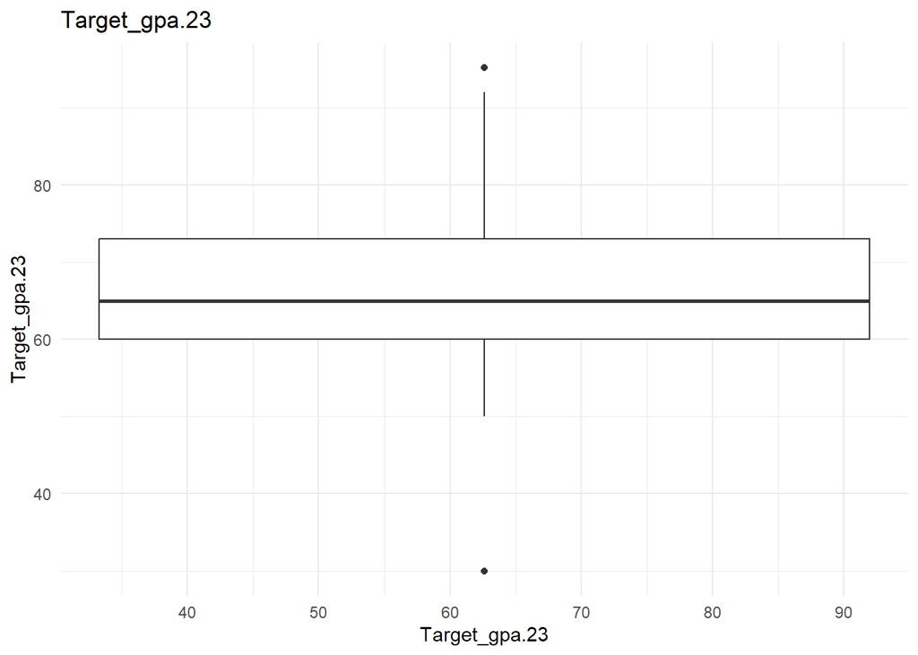

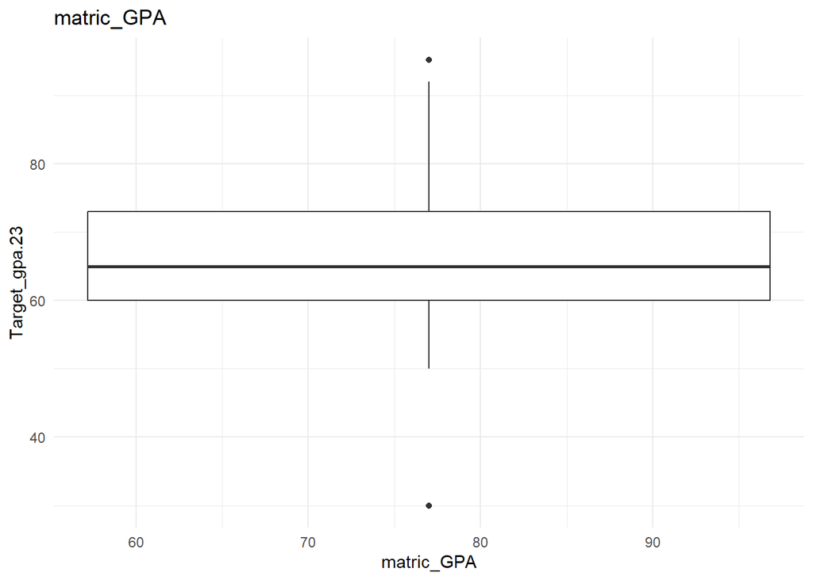

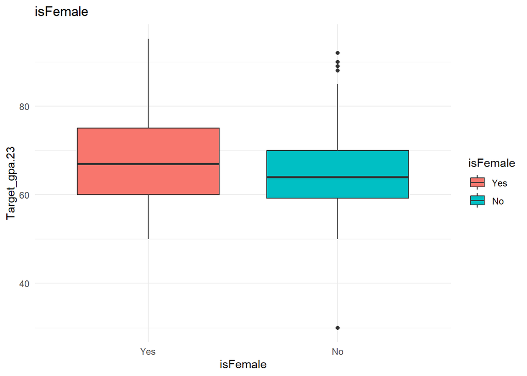

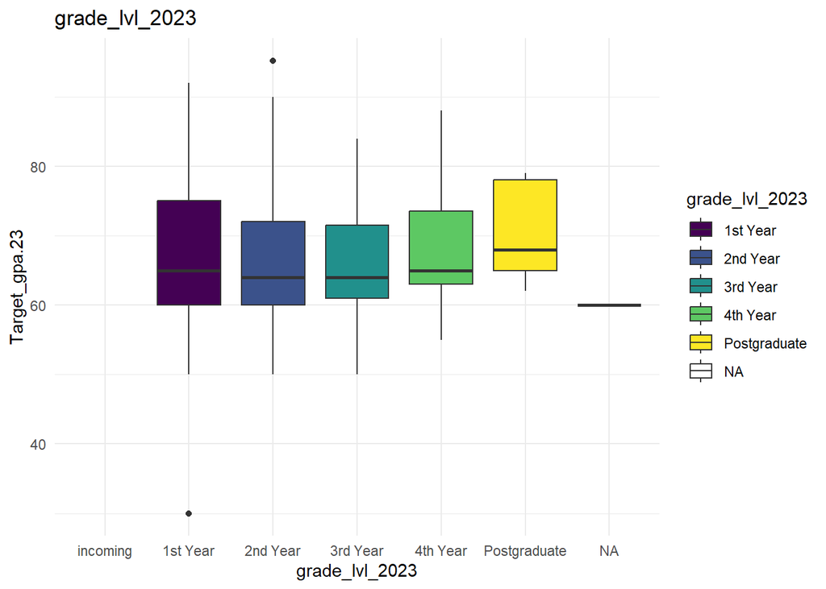

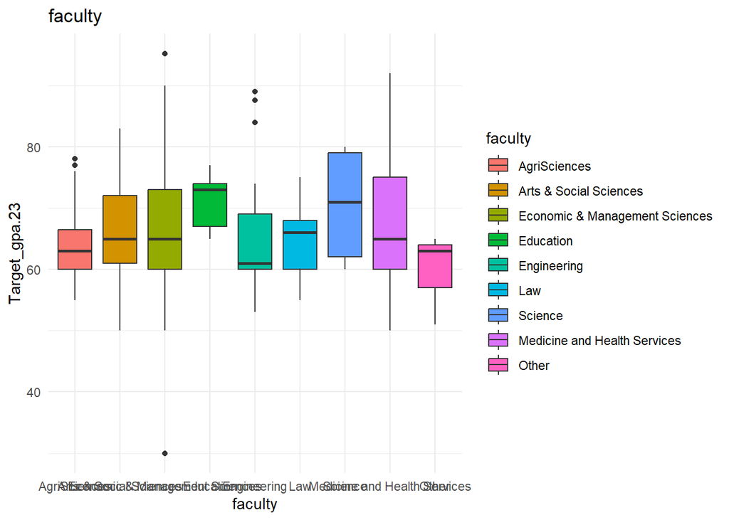

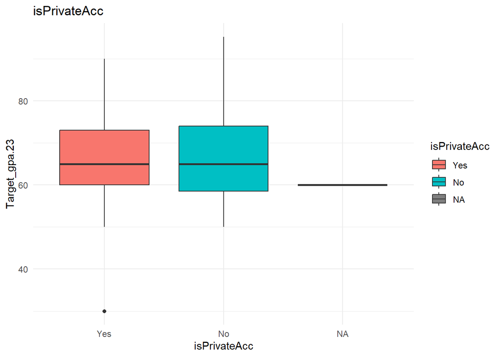

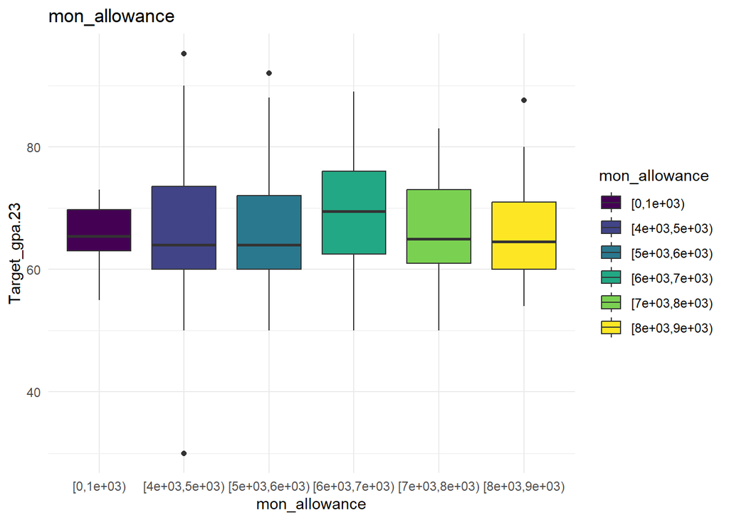

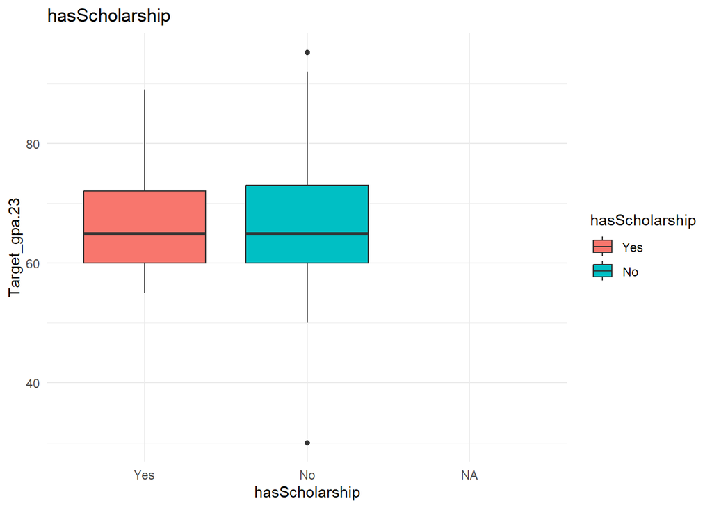

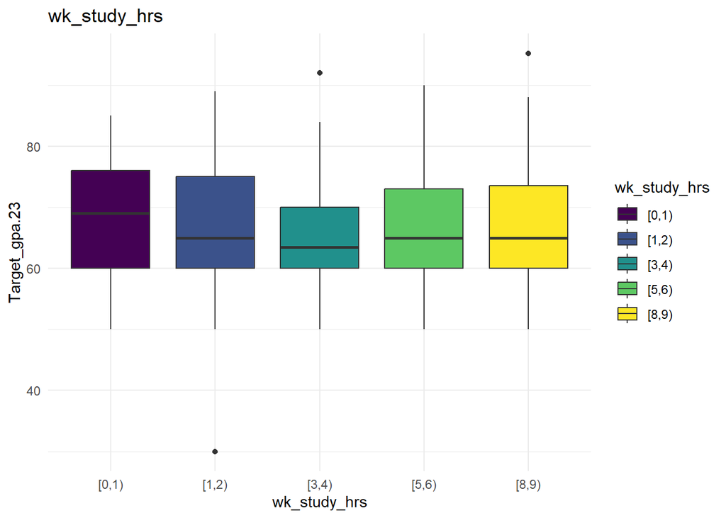

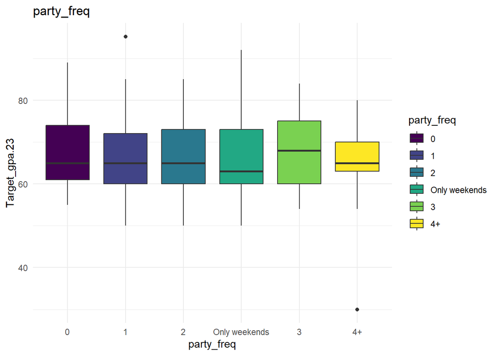

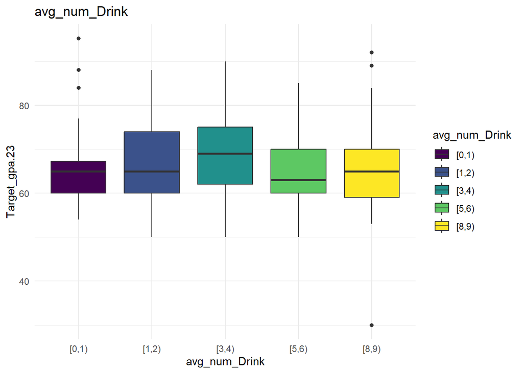

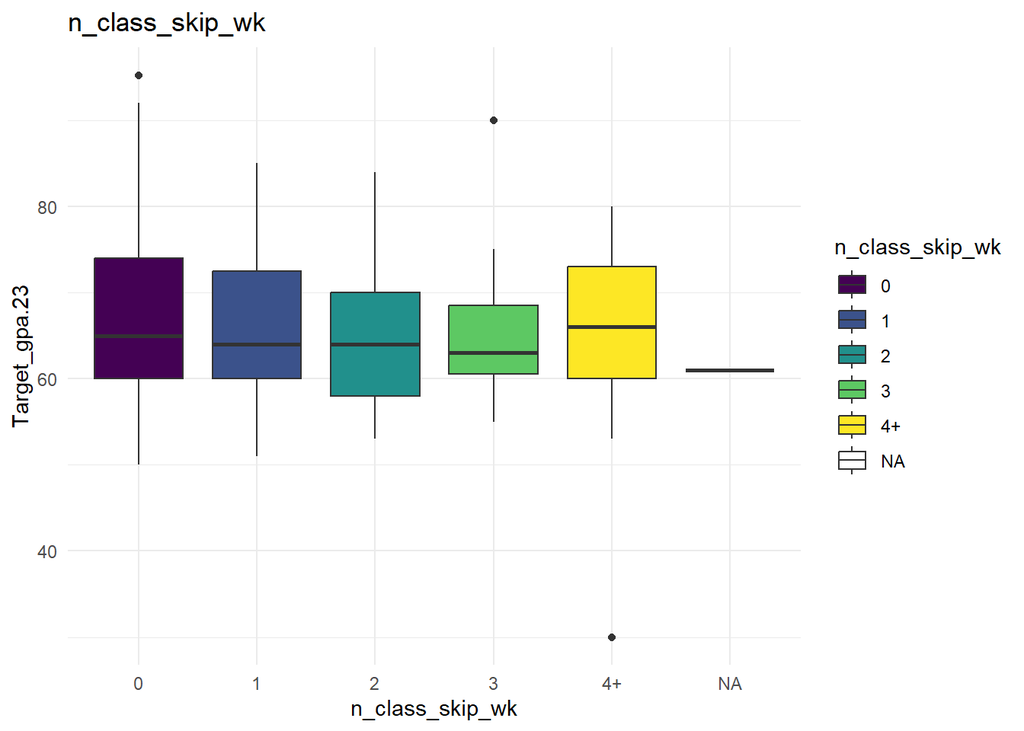

[4 more figures not shown]

Boxplots show a visualization of each factored predictor feature against the continuous target variable, it displays if outliers are present using dots. Even though there are “outliers” clearly present the boxplots have all observation values within their defined ranges. However due to the visualized Target outlier I decided to heck the z-scores of all features to investigate values even if imputation or removed from the dataset for being an “outlier” by the standard z-score of 3.0 is unlikely. The values should be assumed as plausible given the parameters/context.

```
##  Target_gpa.23     matric_GPA grade_lvl_2023 p_Relationship
##              2              2              5              2
```

### 2. Outliers by Feature : |z-Score| > 3.0

|  | Target_gpa.23 | matric_GPA | grade_lvl_2023 | p_Relationship |
| --- | --- | --- | --- | --- |
| 74 | 95.22 | 98.33 | 2nd Year | Close |
| 304 | 30.00 | 67.00 | 1st Year | Very close |
| 255 | NA | 34.00 | incoming | Very close |
| 336 | 61.00 | 55.00 | 2nd Year | Fair |
| 120 | 79.00 | 76.00 | Postgraduate | Very close |
| 139 | 68.00 | 70.00 | Postgraduate | Very close |
| 267 | 62.00 | 82.00 | Postgraduate | Very close |
| 275 | 65.00 | 95.50 | Postgraduate | Fair |
| 358 | 78.00 | 85.00 | Postgraduate | Very close |
| 55 | 89.00 | 98.00 | 1st Year | Distant |
| 117 | 88.00 | 85.00 | 1st Year | Distant |

*note* Boxplot has more values because there are also outliers by category evaluated, but obviously the feature itself have values close to it, as no other outliers were detected at the feature evaluation.

### 3. Histogram Distribution : Evaluate Normality by Feature Density

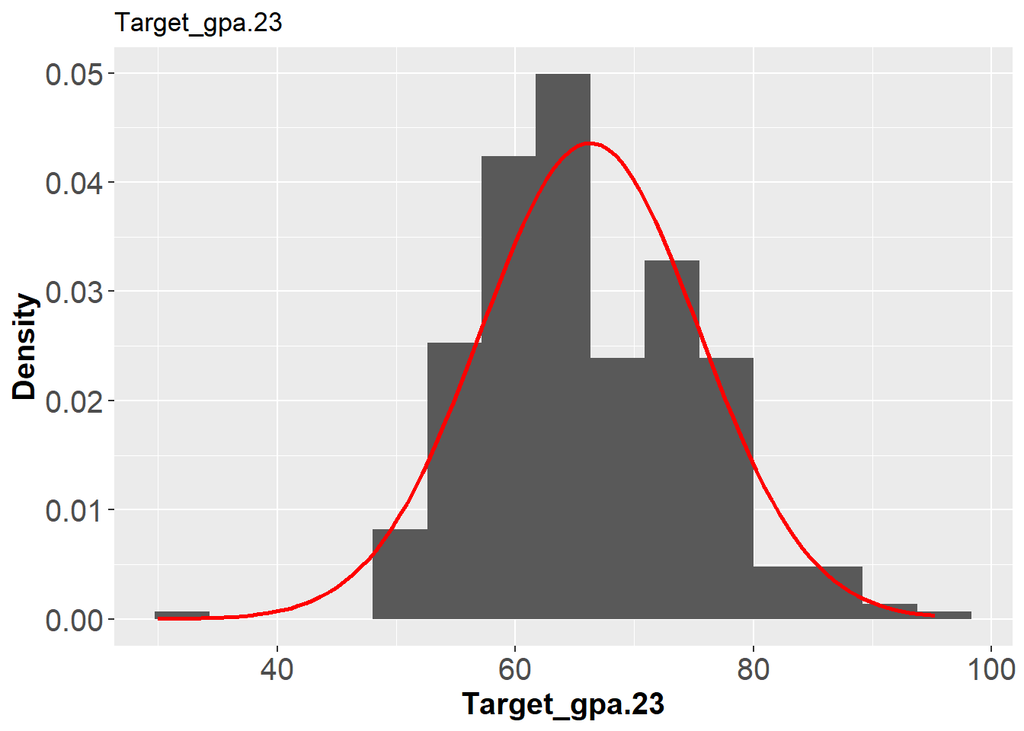

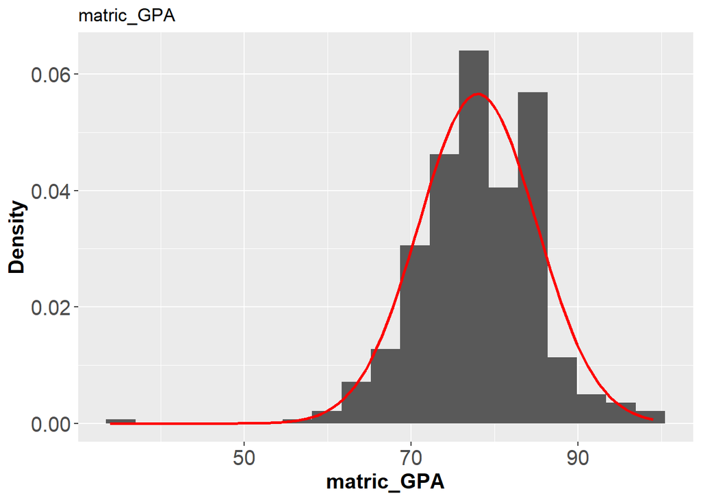

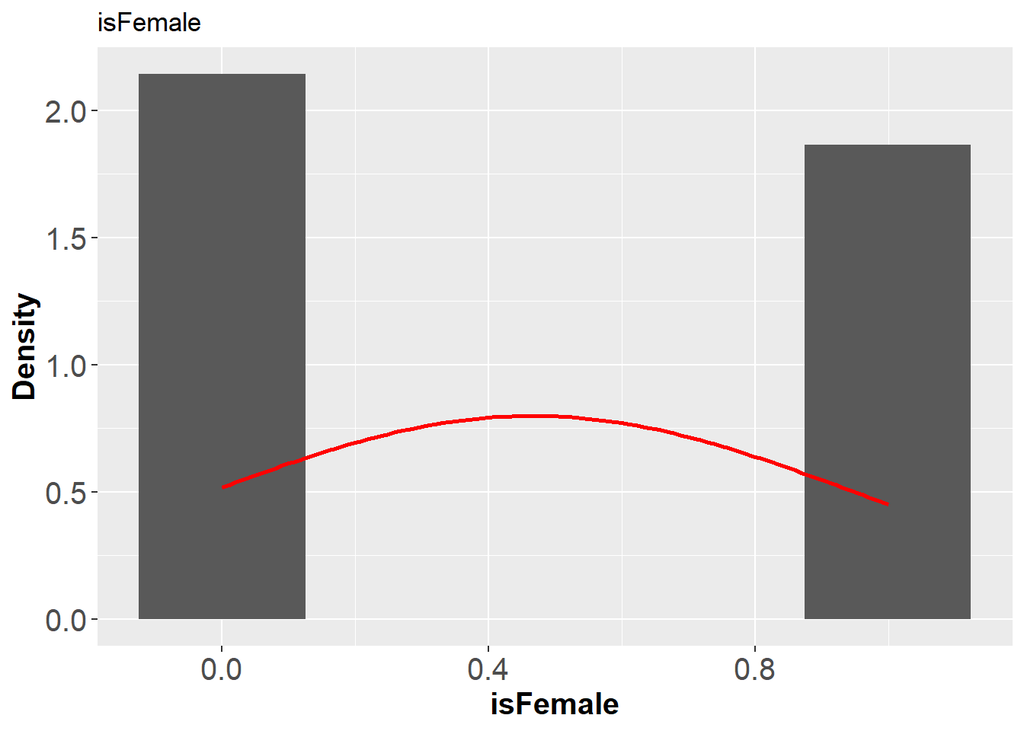

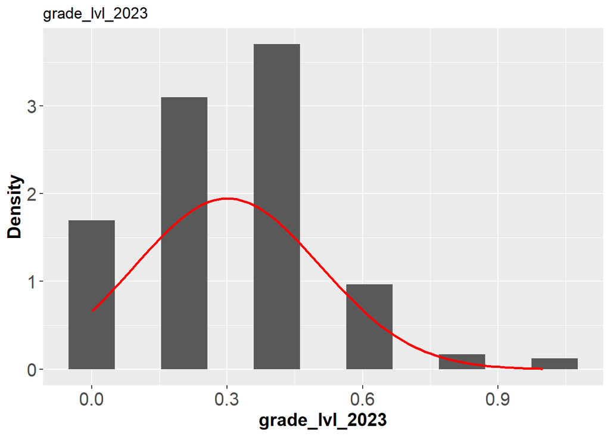

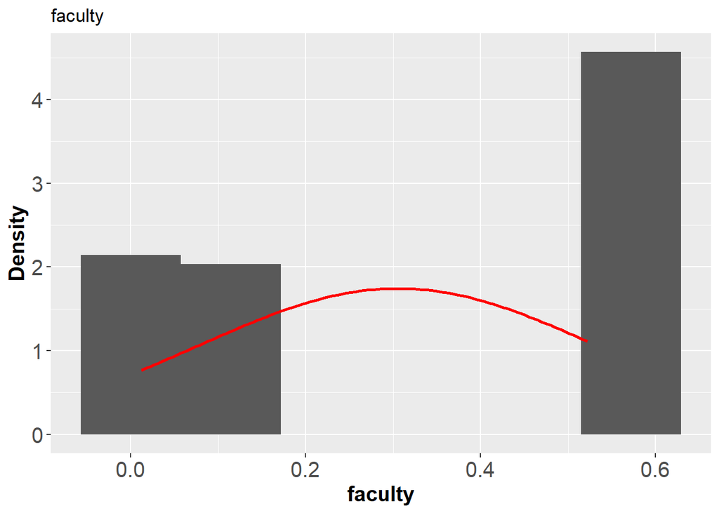

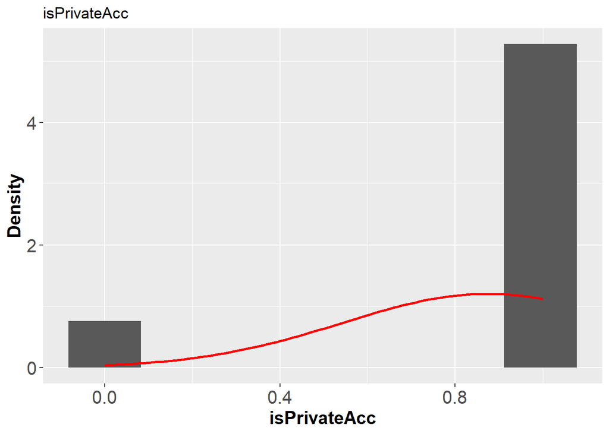

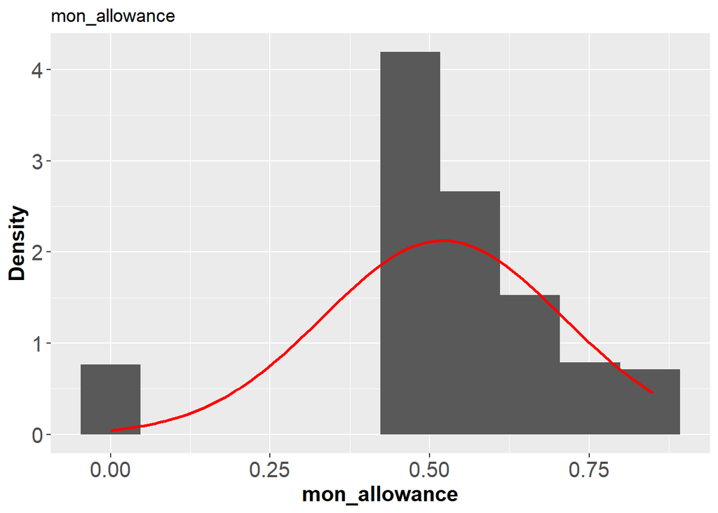

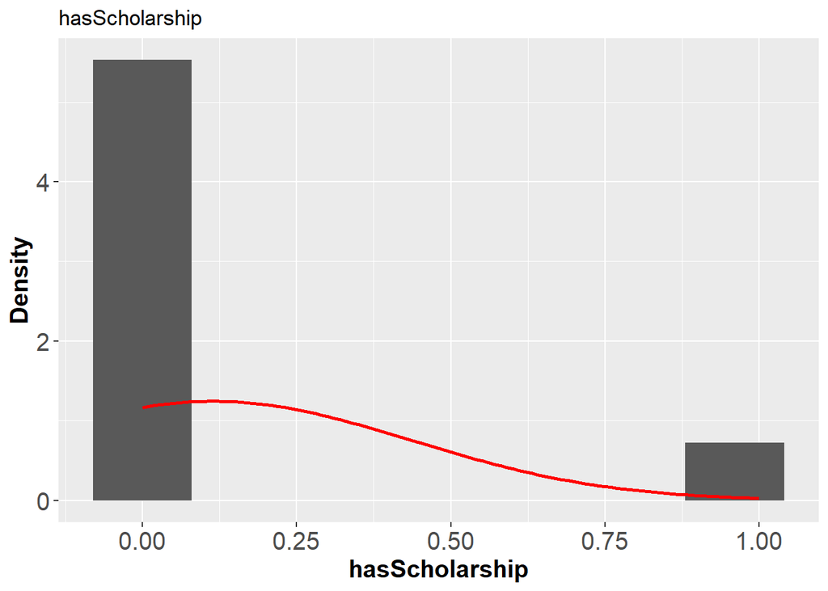